# PCA Analysis of ABS Labour Force per Region

```
This data.table install has not detected OpenMP support. It will work but slower in single threaded mode.
```

The data set is available from the website [LMIP Gov AU](http://lmip.gov.au/default.aspx?LMIP/Downloads/ABSLabourForceRegion).

|  | Region | State | Industry | TotalCount |
| --- | --- | --- | --- | --- |
| 1 | Capital Region | NSW/ACT | Agriculture, Forestry and Fishing | 7200 |
| 2 | Capital Region | NSW/ACT | Mining | 800 |
| 3 | Capital Region | NSW/ACT | Manufacturing | 9500 |
| 4 | Capital Region | NSW/ACT | Electricity, Gas, Water and Waste Services | 2500 |
| 5 | Capital Region | NSW/ACT | Construction | 24400 |
| 6 | Capital Region | NSW/ACT | Wholesale Trade | 4000 |

```
 [1] "Region"
 [2] "State"
 [3] "TotalCount.Agriculture, Forestry and Fishing"
 [4] "TotalCount.Mining"
 [5] "TotalCount.Manufacturing"
 [6] "TotalCount.Electricity, Gas, Water and Waste Services"
 [7] "TotalCount.Construction"
 [8] "TotalCount.Wholesale Trade"
 [9] "TotalCount.Retail Trade"
[10] "TotalCount.Accommodation and Food Services"
[11] "TotalCount.Transport, Postal and Warehousing"
[12] "TotalCount.Information Media and Telecommunications"
[13] "TotalCount.Financial and Insurance Services"
[14] "TotalCount.Rental, Hiring and Real Estate Services"
[15] "TotalCount.Professional, Scientific and Technical Services"
[16] "TotalCount.Administrative and Support Services"
[17] "TotalCount.Public Administration and Safety"
[18] "TotalCount.Education and Training"
[19] "TotalCount.Health Care and Social Assistance"
[20] "TotalCount.Arts and Recreation Services"
[21] "TotalCount.Other Services"
[22] "Location"
```

## Principle components by variance.

|  | component | variance | percent | cumulativePercent |
| --- | --- | --- | --- | --- |
| Comp.1 | 1 | 15.106384947 | 0.7951 | 0.7951 |
| Comp.2 | 2 | 1.205202104 | 0.0634 | 0.8585 |
| Comp.3 | 3 | 0.853931608 | 0.0449 | 0.9034 |
| Comp.4 | 4 | 0.679114257 | 0.0357 | 0.9392 |
| Comp.5 | 5 | 0.464234160 | 0.0244 | 0.9636 |
| Comp.6 | 6 | 0.253136518 | 0.0133 | 0.9769 |
| Comp.7 | 7 | 0.125710513 | 0.0066 | 0.9836 |
| Comp.8 | 8 | 0.096375778 | 0.0051 | 0.9886 |
| Comp.9 | 9 | 0.070695489 | 0.0037 | 0.9924 |
| Comp.10 | 10 | 0.034374305 | 0.0018 | 0.9942 |

[output cut: 9 more lines]

The first five components explain > 95% of the variation, with the first nine components explaining 99% of the variance.

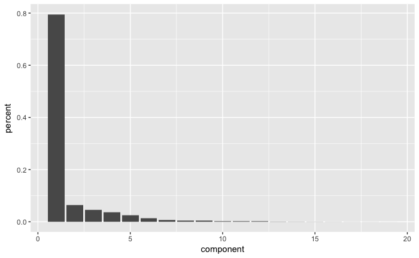

The loadings for each of the industries are shown below.

```
Loadings:
                  Comp.1 Comp.2 Comp.3 Comp.4 Comp.5 Comp.6 Comp.7 Comp.8 Comp.9 Comp.10 Comp.11
AGRIC_FRST_FISH    0.124         0.818 -0.501  0.160 -0.155
MINING                   -0.830  0.115  0.307 -0.208 -0.286         0.174
MANUF             -0.222        -0.251 -0.502               -0.177  0.190  0.380          0.308
UTILITIES         -0.224 -0.302        -0.167         0.554 -0.159 -0.264 -0.591          0.102
CONSTR            -0.245 -0.126 -0.120 -0.163        -0.111  0.378  0.200 -0.178  0.243  -0.668
WSALE_TRADE       -0.247               -0.243 -0.132        -0.211  0.356         0.212
RETAIL_TRADE      -0.254                                     0.104 -0.122  0.301 -0.120  -0.220
ACC_FOOD_SRV      -0.250         0.131  0.101                0.208 -0.386  0.363
TRNS_POST_WHOUSE  -0.228        -0.266 -0.209        -0.587 -0.193 -0.516 -0.184 -0.252
INFO_MEDIA_TELEC  -0.239  0.256  0.145  0.115 -0.191        -0.176                0.329
FIN_INS_SRV       -0.238  0.234  0.159        -0.203 -0.233 -0.169  0.105 -0.262 -0.224
RENT_HIRE_RE_SRV  -0.244  0.126         0.148        -0.143  0.591        -0.186          0.410
PROF_SCI_TECH_SRV -0.241  0.163  0.215  0.215               -0.221  0.216 -0.158          0.110
ADM_SUP_SRV       -0.254                                     0.133         0.105          0.153
PADMIN_SAFETY     -0.197                0.224  0.895 -0.102 -0.117  0.207
EDU_TRAIN         -0.252                              0.212         0.128  0.127 -0.441  -0.341
HEALTH_SOC_ASSIST -0.253                              0.238  0.165               -0.444
ARTS_REC_SRV      -0.244         0.173  0.216         0.120 -0.328 -0.347  0.233  0.399  -0.131
OTHER_SRV         -0.248 -0.164        -0.179                0.174  0.112         0.294   0.176
                  Comp.12 Comp.13 Comp.14 Comp.15 Comp.16 Comp.17 Comp.18 Comp.19
AGRIC_FRST_FISH
MINING
MANUF                     -0.207  -0.259          -0.396                   0.161
UTILITIES                                 -0.125           0.155
CONSTR                            -0.326          -0.105                   0.121
WSALE_TRADE        0.221   0.259          -0.170   0.489   0.110          -0.474
RETAIL_TRADE      -0.155  -0.212   0.232  -0.710   0.202          -0.204   0.175
ACC_FOOD_SRV               0.629  -0.255          -0.138   0.293   0.106
TRNS_POST_WHOUSE                                          -0.118   0.222
INFO_MEDIA_TELEC  -0.265           0.171  -0.217  -0.524  -0.161   0.325  -0.303
FIN_INS_SRV       -0.260   0.159           0.113  -0.121   0.147  -0.666
RENT_HIRE_RE_SRV   0.383  -0.329                           0.119  -0.116  -0.156
PROF_SCI_TECH_SRV  0.257          -0.146  -0.136   0.138           0.375   0.642
ADM_SUP_SRV       -0.620  -0.317  -0.132   0.347   0.415   0.149   0.229
PADMIN_SAFETY
EDU_TRAIN          0.248  -0.127   0.380   0.304           0.373   0.184  -0.191
HEALTH_SOC_ASSIST          0.160  -0.129                  -0.743          -0.179
ARTS_REC_SRV       0.300  -0.254           0.260   0.128  -0.239  -0.297
OTHER_SRV                  0.305   0.668   0.239          -0.148           0.290

               Comp.1 Comp.2 Comp.3 Comp.4 Comp.5 Comp.6 Comp.7 Comp.8 Comp.9 Comp.10 Comp.11
SS loadings     1.000  1.000  1.000  1.000  1.000  1.000  1.000  1.000  1.000   1.000   1.000
Proportion Var  0.053  0.053  0.053  0.053  0.053  0.053  0.053  0.053  0.053   0.053   0.053
Cumulative Var  0.053  0.105  0.158  0.211  0.263  0.316  0.368  0.421  0.474   0.526   0.579
               Comp.12 Comp.13 Comp.14 Comp.15 Comp.16 Comp.17 Comp.18 Comp.19
SS loadings      1.000   1.000   1.000   1.000   1.000   1.000   1.000   1.000
Proportion Var   0.053   0.053   0.053   0.053   0.053   0.053   0.053   0.053
Cumulative Var   0.632   0.684   0.737   0.789   0.842   0.895   0.947   1.000
```

The following plot provides an ordination of the loadings for locations against the industry weightings as the directions of the principle components.

[interactive chart not shown]

That there does seem to be some correspondance between regions and certain industries. We have two codings of data, the first is the long coding (in data1) where industry, and totcal count per industry are allocated between rows, and the second is the wide format with counts captured in the columns with each industry.

We can look at a log linear model for the data set and examine whether there is suggestion to indicate that the interaction between region and industry is signficant.

```r
str(data1)
```

```
'data.frame':   817 obs. of  4 variables:
 $ Region    : Factor w/ 44 levels "Adelaide North",..: 9 9 9 9 9 9 9 9 9 9 ...
 $ State     : Factor w/ 9 levels "","NSW","NSW/ACT",..: 3 3 3 3 3 3 3 3 3 3 ...
 $ Industry  : Factor w/ 19 levels "Accommodation and Food Services",..: 3 12 11 7 5 19 17 1 18 10 ...
 $ TotalCount: num  7200 800 9500 2500 24400 4000 24700 22500 11800 3800 ...
```

We will build a log linear model for this purpose.

Note no offset is used in the model below as the total count is the only count factor (we are predicting $n_i$ for each region and industry interaction).

```r
model1 <- glm(TotalCount ~ Region * Industry, family=poisson(link=log))
summary(model1)
```

```
Call:
glm(formula = TotalCount ~ Region * Industry, family = poisson(link = log))

Deviance Residuals:
  [1]  0  0  0  0  0  0  0  0  0  0  0  0  0  0  0  0  0  0  0  0  0  0  0  0  0  0  0  0  0  0  0  0  0  0  0  0  0  0  0  0
 [41]  0  0  0  0  0  0  0  0  0  0  0  0  0  0  0  0  0  0  0  0  0  0  0  0  0  0  0  0  0  0  0  0  0  0  0  0  0  0  0  0
 [81]  0  0  0  0  0  0  0  0  0  0  0  0  0  0  0  0  0  0  0  0  0  0  0  0  0  0  0  0  0  0  0  0  0  0  0  0  0  0  0  0
[121]  0  0  0  0  0  0  0  0  0  0  0  0  0  0  0  0  0  0  0  0  0  0  0  0  0  0  0  0  0  0  0  0  0  0  0  0  0  0  0  0
[161]  0  0  0  0  0  0  0  0  0  0  0  0  0  0  0  0  0  0  0  0  0  0  0  0  0  0  0  0  0  0  0  0  0  0  0  0  0  0  0  0
[201]  0  0  0  0  0  0  0  0  0  0  0  0  0  0  0  0  0  0  0  0  0  0  0  0  0  0  0  0  0  0  0  0  0  0  0  0  0  0  0  0
[241]  0  0  0  0  0  0  0  0  0  0  0  0  0  0  0  0  0  0  0  0  0  0  0  0  0  0  0  0  0  0  0  0  0  0  0  0  0  0  0  0
[281]  0  0  0  0  0  0  0  0  0  0  0  0  0  0  0  0  0  0  0  0  0  0  0  0  0  0  0  0  0  0  0  0  0  0  0  0  0  0  0  0
[321]  0  0  0  0  0  0  0  0  0  0  0  0  0  0  0  0  0  0  0  0  0  0  0  0  0  0  0  0  0  0  0  0  0  0  0  0  0  0  0  0
[361]  0  0  0  0  0  0  0  0  0  0  0  0  0  0  0  0  0  0  0  0  0  0  0  0  0  0  0  0  0  0  0  0  0  0  0  0  0  0  0  0
[401]  0  0  0  0  0  0  0  0  0  0  0  0  0  0  0  0  0  0  0  0  0  0  0  0  0  0  0  0  0  0  0  0  0  0  0  0  0  0  0  0
[441]  0  0  0  0  0  0  0  0  0  0  0  0  0  0  0  0  0  0  0  0  0  0  0  0  0  0  0  0  0  0  0  0  0  0  0  0  0  0  0  0
[481]  0  0  0  0  0  0  0  0  0  0  0  0  0  0  0  0  0  0  0  0  0  0  0  0  0  0  0  0  0  0  0  0  0  0  0  0  0  0  0  0
[521]  0  0  0  0  0  0  0  0  0  0  0  0  0  0  0  0  0  0  0  0  0  0  0  0  0  0  0  0  0  0  0  0  0  0  0  0  0  0  0  0
[561]  0  0  0  0  0  0  0  0  0  0  0  0  0  0  0  0  0  0  0  0  0  0  0  0  0  0  0  0  0  0  0  0  0  0  0  0  0  0  0  0
[601]  0  0  0  0  0  0  0  0  0  0  0  0  0  0  0  0  0  0  0  0  0  0  0  0  0  0  0  0  0  0  0  0  0  0  0  0  0  0  0  0
[641]  0  0  0  0  0  0  0  0  0  0  0  0  0  0  0  0  0  0  0  0  0  0  0  0  0  0  0  0  0  0  0  0  0  0  0  0  0  0  0  0
[681]  0  0  0  0  0  0  0  0  0  0  0  0  0  0  0  0  0  0  0  0  0  0  0  0  0  0  0  0  0  0  0  0  0  0  0  0  0  0  0  0
[721]  0  0  0  0  0  0  0  0  0  0  0  0  0  0  0  0  0  0  0  0  0  0  0  0  0  0  0  0  0  0  0  0  0  0  0  0  0  0  0  0
[761]  0  0  0  0  0  0  0  0  0  0  0  0  0  0  0  0  0  0  0  0  0  0  0  0  0  0  0  0  0  0  0  0  0  0  0  0  0  0  0  0
[801]  0  0  0  0  0  0  0  0  0  0  0  0  0  0  0  0  0

Coefficients:
                                                                                                      Estimate Std. Error
(Intercept)                                                                                          9.847e+00  7.274e-03
RegionAdelaide South                                                                                 2.093e-01  9.789e-03
RegionBallarat                                                                                      -9.933e-01  1.399e-02
RegionBarwon                                                                                        -8.350e-01  1.322e-02
RegionBendigo                                                                                       -1.271e+00  1.554e-02
RegionBrisbane South East                                                                            3.342e-01  9.528e-03
RegionCairns                                                                                        -7.874e-01  1.301e-02
RegionCapital Region                                                                                 1.744e-01  9.867e-03
RegionCentral West                                                                                  -1.216e+00  1.521e-02
RegionDarling Downs                                                                                 -8.109e-01  1.311e-02
RegionDarwin                                                                                        -1.115e+00  1.464e-02
RegionFar West Orana                                                                                -1.330e+00  1.590e-02
```

[output cut: 385 more lines]

```
RegionDarwin:IndustryConstruction                                                                      7.578 3.51e-14 ***
RegionFar West Orana:IndustryConstruction                                                            -18.550  < 2e-16 ***
RegionFitzroy:IndustryConstruction                                                                     0.326 0.744449
RegionGippsland:IndustryConstruction                                                                 -14.913  < 2e-16 ***
 [ reached getOption("max.print") -- omitted 617 rows ]
---
Signif. codes:  0 ‘***’ 0.001 ‘**’ 0.01 ‘*’ 0.05 ‘.’ 0.1 ‘ ’ 1

(Dispersion parameter for poisson family taken to be 1)

    Null deviance: 1.3238e+07  on 816  degrees of freedom
Residual deviance: 3.9482e-10  on   0  degrees of freedom
AIC: 10302

Number of Fisher Scoring iterations: 22
```

Note that this is the full model, since there is 0 residual deviance. We use the analysis of deviance to determine whether region does provide a significant explanation of deviance.

```r
anova(model1, test="Chisq")
```

```
Analysis of Deviance Table

Model: poisson, link: log

Response: TotalCount

Terms added sequentially (first to last)

                 Df Deviance Resid. Df Resid. Dev  Pr(>Chi)
NULL                               816   13238453
Region           42  6990537       774    6247916 < 2.2e-16 ***
Industry         18  4597522       756    1650394 < 2.2e-16 ***
Region:Industry 756  1650394         0          0 < 2.2e-16 ***
---
Signif. codes:  0 ‘***’ 0.001 ‘**’ 0.01 ‘*’ 0.05 ‘.’ 0.1 ‘ ’ 1
```

Examining the p-values above, we can see that all of the terms, region, industry and the interaction term are all significant in accounting for deviance, hence there is evidence to suggest regional influence on the proportions represented within each industry.

This could be accounted for by differences in population as well at such a summary level, although if we inspect the z-values for the coefficients above we can gain some insight into the significance of the individual interactions. These values are useful given the significance of the interaction term as determined from the analysis of deviance above.

The predictive aspect of this model allows for example an industry and region pair to be selected and the expected proportion of the population to be predicted.

For example, demonstrating the fit of the profession “Professional, Scientific and Technical Services” accross several regions :

```r
model2 <- glm(TotalCount ~ Region + Industry, family=poisson(link=log))
```

```r
p1 <- predict(model1, subset, type="response")
p2 <- predict(model2, subset, type="response")
plot(TotalCount ~ Region, main="Professional, Scientific and Tech services Count per region")
points(p1 ~ Region, col="blue")
```

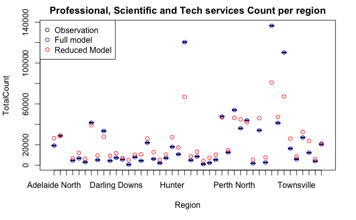

```r
points(p2 ~ Region, col="red")
legend("topleft", legend=c("Observation", "Full model", "Reduced Model"), col=c("black", "blue", "red"), pch=c(1,1,1))
```

We can inspect the scaled residuals for the reduced model (although somewhat less effective for the GLM rather than OLS).

```r
par.old <- par(mfrow=c(1,2))
r <- resid(model2)
scalefit <- 2*sqrt(fitted(model2))
plot(r ~ scalefit, ylab="Deviance residuals", xlab="Scaled fitted values")
qqnorm(r)
```

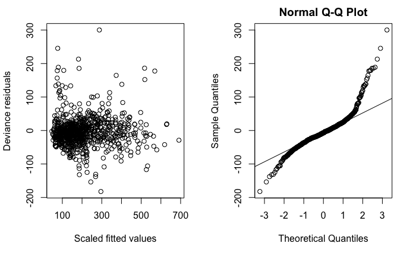

```r
qqline(r)
par(par.old)
```

We can see the normality assumption is violated as there appears to be influential points at the upper and lower ranges. We can check to determine which points may in fact be highly influential.

Using the cooks distance we can look for leverage points.

```r
d1 <- cooks.distance(model2)
d2 <- dffits(model2)
hat <- hatvalues(model2)
p <- length(model2$coefficients)
n <- nrow(data1)
h1 <- 2*p/n
h2 <- 2*p/n
c1 <- qf(0.5,p,n-p)
dt <- -2*sqrt(p/n)
par.old <- par(mfrow=c(3,1))
plot(diag(hat), type="h", main="Diagonal of Hat values", ylim=c(0, max(c(diag(hat), h1, h2))))
abline(h=h1, col="red")
```

```r
abline(h=h2, col="red")
plot(d1, type="h", main="Cooks Distance", ylim=c(0,max(d1, c1)))
```

```r
abline(h=c1, col="red")
plot(d2, type="h", main="DFFITS", ylim=c(-1*(max(d2, dt)), max(d2, dt)))
```

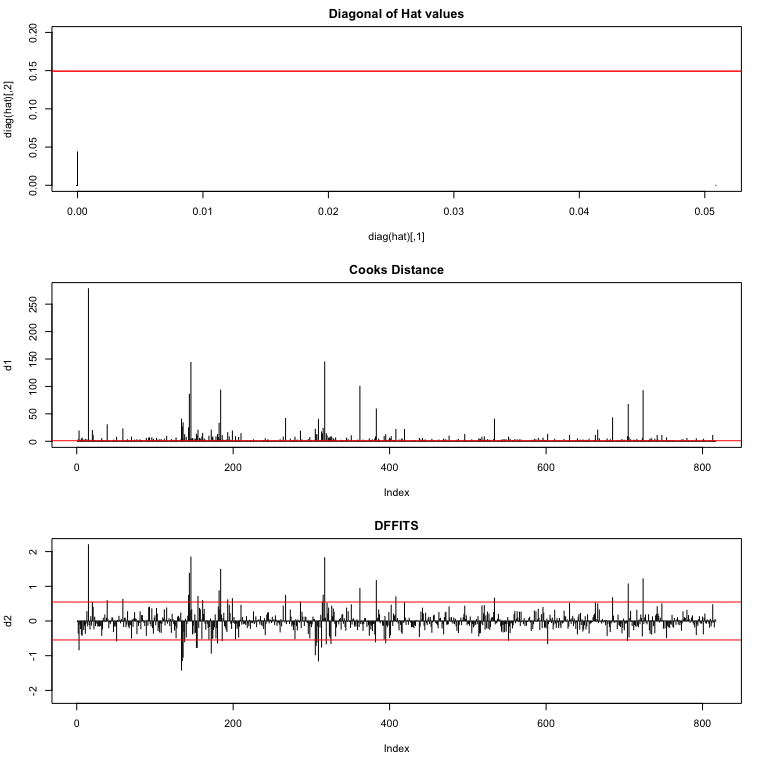

```r
abline(h=-dt, col="red")
abline(h=dt, col="red")
```

Based on cooks distance alone it appears that there are a large number of leverage points, however the dffits may be a more reasonable heuristic to look for leverage points. We can select these as follows.

```r
test <- which(abs(d2) > abs(dt))
data1[test,]
```

|  | Region | State | Industry | TotalCount |
| --- | --- | --- | --- | --- |
| 3 | Capital Region | NSW/ACT | Manufacturing | 9500 |
| 15 | Capital Region | NSW/ACT | Public Administration and Safety | 77200 |
| 39 | Far West Orana | NSW | Agriculture, Forestry and Fishing | 10500 |
| 51 | Far West Orana | NSW | Professional, Scientific and Technical Services | 600 |
| 59 | Hunter | NSW | Mining | 17200 |
| 134 | Sydney East Metro | NSW | Agriculture, Forestry and Fishing | 1400 |
| 135 | Sydney East Metro | NSW | Mining | 800 |
| 136 | Sydney East Metro | NSW | Manufacturing | 44600 |
| 138 | Sydney East Metro | NSW | Construction | 67700 |
| 143 | Sydney East Metro | NSW | Information Media and Telecommunications | 30700 |

[output cut: 36 more lines]

Note that the data points selected via the DFFITS measure (difference in the fitted value standardised), gives some sense as to which combinations of regions and industries can be considered leverage points in the data set. There are a number of possibilities for this, among them the total count for the region and industry pair is very high or very low.

These points may also correspond to the PCA ordination as being at the extremes of each of the principle components, although visual inspection may be required to confirm this intuition.

We can also compare to the mean counts per region.

```r
detach(subset)
```

```r
require(dplyr)
means <- data1 %>%
  group_by(Region) %>%
  summarise(MeanTotal=mean(TotalCount))
means
```

| Region | MeanTotal |
| --- | --- |
| Adelaide North | 16010.526 |
| Adelaide South | 17578.947 |
| Ballarat | 4100.000 |
| Barwon | 7300.000 |
| Bendigo | 3710.526 |
| Brisbane South East | 23800.000 |
| Cairns | 5847.368 |
| Capital Region | 16852.632 |
| Central West | 5557.895 |
| Darling Downs | 7094.737 |

[output cut: 33 more lines]

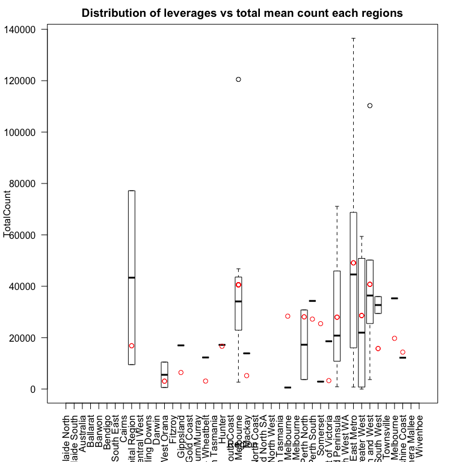

```r
temp <- data1[test,]
temp1 <- merge(means, temp, by="Region")
attach(temp1)
plot(TotalCount ~ Region, main="Distribution of leverages vs total mean count each regions", las=2, srt=60)
points(MeanTotal ~ Region, col="red")
```

This gives some indication of which regions contain leverage points that are below the regional mean and those which are above.